# Case Study: Dimarta Clinical Trial

Basel R Bootcamp, July 2018 [www.therbootcamp.com](https://therbootcamp.github.io) [@therbootcamp](https://twitter.com/therbootcamp)

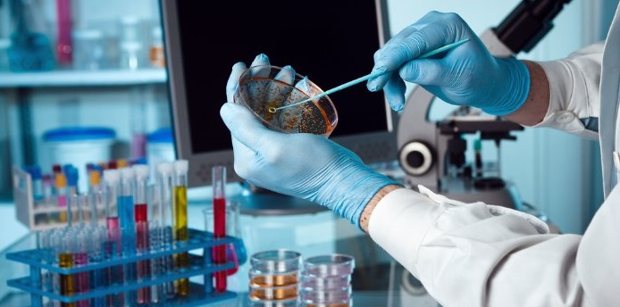

[source](http://www.formerfda.com/wp-content/uploads/2014/08/clinical-trials.jpg)

### Overview

In this case study, we will look at the results of a clinical trial exploring the effectiveness of a new medication called dimarta on reducing histamine in patients with a disease that leads to chronically high histamine levels. In the study, 300 patients were assigned to one of three different treatment arms. One arm was given a placebo. The other arm was given adiclax – the standard of care for the disease. Finally, the third arm was given dimarta. There were two main measures of interest in the trial: patient’s changes in histamine from the beginning to the end of the trial, and their change in quality of life (measured by self report).

In addition to exploring the effects of the three medications, the researchers are interested in the extent to which three different biomarkers, dw, ms, and np, are correlated with therapeutic outcomes. In other words, to patients that express one or more of these biomarkers have better, or worse, outcomes that those that do not express these biomarkers?

### Datasets

```r
library(tidyverse)
library(haven)
```

| File | Rows | Columns | Description |
| --- | --- | --- | --- |
| dimarta_trial.csv | 300 | 6 | Key DIMARTA trial outcomes |
| dimarta_biomarker.csv | 900 | 3 | Biomarker status’ for 3 different biomarkers for each patient. |
| dimarta_demographics.csv | 300 | 5 | Demographic information for each patient |

Column Descriptions

**dimarta_trial.csv**

Table1. `dimarta_trial.csv` variable description:

| Variable | Description |
| --- | --- |
| PatientID | Unique patient id |
| arm | Treatment arm, either 1 = placebo, 2 = adiclax (the standard of treatment), or 3 = dimarta (the target drug) |
| histamine_start | histamine value at the start of the trial |
| histamine_end | histamine value at the end of the trial |
| qol_start | Patient’s rated quality of life at the start of the trial |
| qol_end | Patient’s rated quality of life at the end of the trial |

**dimarta_demographics.csv**

Table2. `dimarta_demographics.csv` variable description:

| Variable | Description |
| --- | --- |
| PatientID | Unique patient id |
| age | Patient age |
| gender | Patient gender, 0 = male, 1 = female |
| site | Site where the clinical trial was conducted |
| diseasestatus | Status of the patient’s disease at start of trial |

**dimarta_biomarker.csv**

Table3. `dimarta_biomarker.csv` variable description:

| Variable | Description |
| --- | --- |
| PatientID | Unique patient id |
| Biomarker | One of three biomarkers: dw, ms, and np |
| BiomarkerStatus | Result of the test for the biomarker. |

# Tasks

## A - Getting Setup

1. Open your `baselrbootcamp` R project. It should already have the folders `1_Data` and `2_Code`.
2. Open a new R script and save it as a new file in your `R` folder called `dimarta_casestudy.R`. At the top of the script, using comments, write your name and the date. Then, load the `tidyverse` package. Here’s how the top of your script should look:

```r
## My Name
## The Date
## Dimarta - Case Study

library(tidyverse)
```

## B - Data I/O

2. Using `read_csv()`, load the `dimarta_trial.csv`, `dimarta_demographics.csv`, and `dimarta_biomarker.csv` datasets as *three* new objects called `trial_df`, `demographics_df`, and `biomarker_df`.

```r
## read in datasets
trial_df <- read_csv("1_Data/dimarta_trial.csv")
```

```r
demographics_df <- read_csv("1_Data/dimarta_demographics.csv")
biomarker_df <- read_csv("1_Data/dimarta_biomarker.csv")
```

3. Get a first impression of the objects you just created by exploring them with a mixture of the `View()`, `head()`, `names()`, and `str()` functions. Were they all loaded correctly?

```r
trial_df
```

```
# A tibble: 300 x 6
   PatientID   arm histamine_start histamine_end qol_start qol_end
   <chr>     <int>           <dbl>         <dbl>     <int>   <int>
 1 txdjezeo      1            58.6          67.0         3       3
 2 htxfjlxk      3            36.1          28.0         3       4
 3 vkdqhyez      1            57.7          57.3         2       2
 4 dbuvrwfq      3            56.6          57.4         2       3
 5 ydaitaah      2            64.7          67.9         5       7
 6 omhxokdr      1            37.4          41.7         2       2
 7 dsybafny      1            88.4          95.9         4       6
 8 fdfmcoto      2            20.2          18.9         2       2
 9 rwsbykxe      2            48.3          43.0         3       3
10 xocueqqe      3            48.6          55.2         1       1
# ... with 290 more rows
```

```r
demographics_df
```

```
# A tibble: 300 x 5
   PatientID   age gender site   diseasestatus
   <chr>     <int>  <int> <chr>  <chr>
 1 pkyivajv     36      0 Tokyo  Mid
 2 dbuvrwfq     39      0 Paris  Late
 3 jhuztppp     30      0 Tokyo  Mid
 4 qejexgza     34      1 Tokyo  Late
 5 cszrjxju     41      1 Tokyo  Late
 6 uhvgttqh     31      0 London Late
 7 cflnybdw     45      1 Tokyo  Mid
 8 igobmmvj     48      0 Tokyo  Late
 9 lcrtmerg     35      0 London Late
10 fjjrnsnt     43      1 London Mid
# ... with 290 more rows
```

```r
biomarker_df
```

```
# A tibble: 900 x 3
   PatientID Biomarker BiomarkerStatus
   <chr>     <chr>     <lgl>
 1 ygazqssv  dw        FALSE
 2 qosueuyw  ms        FALSE
 3 bhhykjvw  ms        FALSE
 4 ifajorty  np        TRUE
 5 gxnsybdt  ms        FALSE
 6 igobmmvj  ms        FALSE
 7 knnzlzun  ms        FALSE
 8 glzcbmby  ms        FALSE
 9 gxnsybdt  dw        TRUE
10 fzrhdpdu  np        FALSE
# ... with 890 more rows
```

## C - Data Wrangling

1. Using `rename()`, change the name of the column `arm` in the `trial_df` data to `StudyArm`.

```r
trial_df <- trial_df %>%
  rename(StudyArm = arm)
```

2. Using the `table()` function, look at the values of the `StudyArm` column in `trial_df`. You’ll notice the values are 1, 2, and 3. Using `mutate()` and `case_when()` change these values to the appropriate names of the study arms (look at the variable descriptions to see which is which!)

```r
trial_df <- trial_df %>%
  mutate(StudyArm = case_when(
    StudyArm == 1 ~ "placebo",
    StudyArm == 2 ~ "adiclax",
    StudyArm == 3 ~ "dimarta"
  ))
```

3. In the `demographics_df` data, you’ll see that gender is coded as 0 and 1. Using `mutate()` create a *new* column in `demographics_df` called `gender_c` that shows gender as a string, where 0 = “male”, and 1 = “female”.

```r
demographics_df <- demographics_df %>%
  mutate(gender_c = case_when(
    gender == 0 ~ "male",
    gender == 1 ~ "female"
  ))
```

4. Now let’s create a new object called `dimarta_df` that combines data from `trial_df` and `demographics_df`. To do this, use `left_join()` to combine the `trial_df` data with the `demographics_df` data. This will merge the two datasets so you can have the study results and demographic data in the same dataframe. Make sure to assign the result to a new object called `dimarta_df`

```r
# Create a new dataframe called dimarta_df that contains both trial_df and demographics_df
dimarta_df <- trial_df %>%
  left_join(demographics_df)
```

5. You’ll notice that the `biomarker_df` dataframe is in the ‘long’ format, where each row is a patient’s biomarker result. Using the code below, making use of the `spread()` function, create a new dataframe called `biomarker_wide_df` where each row is a patient, and the results from different biomarkers are in different columns. When you finish, look at `biomarker_wide_df` to see how it looks!

```r
# Convert biomarker_df to a wide format using spread()
biomarker_wide_df <- biomarker_df %>%
  spread(Biomarker, BiomarkerStatus)

biomarker_wide_df
```

```
# A tibble: 300 x 4
   PatientID dw    ms    np
   <chr>     <lgl> <lgl> <lgl>
 1 aiadwpbo  FALSE FALSE FALSE
 2 ajshuufj  FALSE FALSE FALSE
 3 ammweoxu  FALSE FALSE FALSE
 4 amzacliz  FALSE FALSE FALSE
 5 apeddxgo  TRUE  FALSE FALSE
 6 aqadnoup  TRUE  FALSE FALSE
 7 arinkxww  FALSE FALSE FALSE
 8 arpvtvxl  FALSE FALSE FALSE
 9 asquxnty  FALSE FALSE TRUE
10 atzluemr  FALSE FALSE FALSE
# ... with 290 more rows
```

6. Now, using the `left_join` function, add the `biomarker_wide_df` data to the `dimarta_df` data! Now you should hve all of the data in a single dataframe called `dimarta_df`

```r
dimarta_df <- dimarta_df %>%
  left_join(biomarker_wide_df)
```

```r
dimarta_df
```

```
# A tibble: 300 x 14
   PatientID StudyArm histamine_start histamine_end qol_start qol_end   age
   <chr>     <chr>              <dbl>         <dbl>     <int>   <int> <int>
 1 txdjezeo  placebo             58.6          67.0         3       3    39
 2 htxfjlxk  dimarta             36.1          28.0         3       4    42
 3 vkdqhyez  placebo             57.7          57.3         2       2    47
 4 dbuvrwfq  dimarta             56.6          57.4         2       3    39
 5 ydaitaah  adiclax             64.7          67.9         5       7    35
 6 omhxokdr  placebo             37.4          41.7         2       2    41
 7 dsybafny  placebo             88.4          95.9         4       6    35
 8 fdfmcoto  adiclax             20.2          18.9         2       2    50
 9 rwsbykxe  adiclax             48.3          43.0         3       3    35
10 xocueqqe  dimarta             48.6          55.2         1       1    42
# ... with 290 more rows, and 7 more variables: gender <int>, site <chr>,
#   diseasestatus <chr>, gender_c <chr>, dw <lgl>, ms <lgl>, np <lgl>
```

8. Using the `mean()` function, calculate the mean age of all patients.

```r
mean(dimarta_df$age)
```

```
[1] 39.9
```

9. Using the following template, find out how many male and female patients were in the trial.

```r
dimarta_df %>%
  group_by(XXX) %>%
  summarise(
    Counts = n()
  )
```

```r
dimarta_df %>%
  group_by(gender_c) %>%
  summarise(
    Counts = n()
  )
```

```
# A tibble: 2 x 2
  gender_c Counts
  <chr>     <int>
1 female      140
2 male        160
```

10. Now, using similar code, find out how many patients were assigned to each study arm.

```r
dimarta_df %>%
  group_by(StudyArm) %>%
  summarise(
    Counts = n()
  )
```

```
# A tibble: 3 x 2
  StudyArm Counts
  <chr>     <int>
1 adiclax     100
2 dimarta     100
3 placebo     100
```

11. Find out how many men and women were assigned to each study arm (Hint: You can use very similar code to what you used above, just add a second grouping variable!)

```r
dimarta_df %>%
  group_by(StudyArm, gender_c) %>%
  summarise(
    Counts = n()
  )
```

```
# A tibble: 6 x 3
# Groups:   StudyArm [?]
  StudyArm gender_c Counts
  <chr>    <chr>     <int>
1 adiclax  female       41
2 adiclax  male         59
3 dimarta  female       49
4 dimarta  male         51
5 placebo  female       50
6 placebo  male         50
```

12. Using `mutate()`, add a new column to the `dimarta_df` data called `histamine_change` that shows the *change* in patient’s histamine levels from the start to the end of the trial (Hint: just subtract `histamine_start` from `histamine_end`!)

```r
dimarta_df <- dimarta_df %>%
  mutate(
    histamine_change = histamine_end - histamine_start
  )

# Look at result
dimarta_df %>%
  select(histamine_change)
```

```
# A tibble: 300 x 1
   histamine_change
              <dbl>
 1            8.4
 2           -8.12
 3           -0.39
 4            0.760
 5            3.25
 6            4.34
 7            7.47
 8           -1.35
 9           -5.32
10            6.58
# ... with 290 more rows
```

13. Using `mutate()` again, add a new column to `dimarta_df` called `qol_change` that shows the change in patient’s quality of life.

```r
dimarta_df <- dimarta_df %>%
  mutate(
    qol_change = qol_end - qol_start
  )

# Look at result
dimarta_df %>%
  select(qol_change)
```

```
# A tibble: 300 x 1
   qol_change
        <int>
 1          0
 2          1
 3          0
 4          1
 5          2
 6          0
 7          2
 8          0
 9          0
10          0
# ... with 290 more rows
```

14. Calculate the percentage of patients who tested positive for each of the three biomarkers using the following template (Hint: If you calculate the `mean()` of a logical vector, you will get the percentage of TRUE values!)

```r
# Calculate percent of patients with positive biomarkers

dimarta_df %>%
  summarise(
    dw_mean = mean(XXX),
    ms_percent = mean(XXX),
    np_percent = mean(XXX)
  )
```

```r
# Calculate percent of patients with positive biomarkers

dimarta_df %>%
  summarise(
    dw_mean = mean(dw),
    ms_percent = mean(ms),
    np_percent = mean(np)
  )
```

```
# A tibble: 1 x 3
  dw_mean ms_percent np_percent
    <dbl>      <dbl>      <dbl>
1   0.257       0.19      0.233
```

15. Were there different distributions of age in the different trial sites? To answer this, separately calculate the mean and standard deviations of patient ages in each site. (Hint: group the data by `site`, then calculate two separate summary statistics: `age_mean = mean(age)`, and `age_sd = sd(age)`.

```r
# Calculate the mean change in histamine for each study site
dimarta_df %>%
  group_by(site) %>%
  summarise(
    age_mean = mean(age),
    age_sd = sd(age)
  )
```

```
# A tibble: 3 x 3
  site   age_mean age_sd
  <chr>     <dbl>  <dbl>
1 London     39.9   5.86
2 Paris      39.8   4.84
3 Tokyo      40.1   4.50
```

16. Calculate the mean change in histamine results separately for each study site

```r
# Calculate the mean change in histamine for each study site
dimarta_df %>%
  group_by(site) %>%
  summarise(
    histamine_change_mean = mean(histamine_change, na.rm = TRUE)
  )
```

```
# A tibble: 3 x 2
  site   histamine_change_mean
  <chr>                  <dbl>
1 London                  1.99
2 Paris                   2.29
3 Tokyo                   1.29
```

17. Calculate the mean change in histamine results (`histamine_change`) for each study arm. Which study arm had a largest decrease in histamine?

```r
# Calculate the mean change in histamine for each study site
dimarta_df %>%
  group_by(StudyArm) %>%
  summarise(
    histamine_change_mean = mean(histamine_change, na.rm = TRUE)
  )
```

```
# A tibble: 3 x 2
  StudyArm histamine_change_mean
  <chr>                    <dbl>
1 adiclax                  0.210
2 dimarta                  2.51
3 placebo                  2.90
```

18. Calculate the mean change in quality of life (`qol_change`) for each study arm. Do the results match what you found with the histamine results?

```r
# Calculate the mean change in histamine for each study site
dimarta_df %>%
  group_by(StudyArm) %>%
  summarise(
    qol_change_mean = mean(qol_change, na.rm = TRUE)
  )
```

```
# A tibble: 3 x 2
  StudyArm qol_change_mean
  <chr>              <dbl>
1 adiclax             0.06
2 dimarta             0.01
3 placebo            -0.15
```

## D - Plotting

1. Run the following code block to visualise the relationship between study arm and histamine change. What do you find?

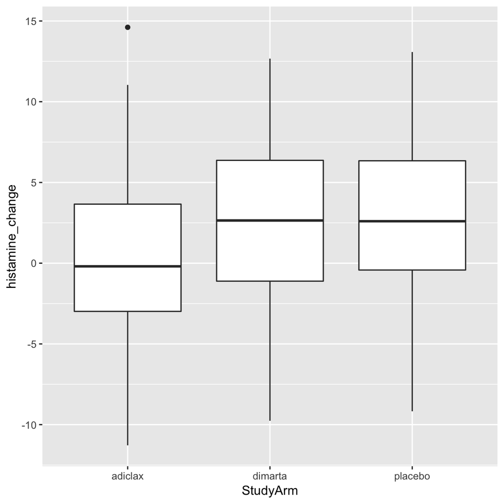

```r
ggplot(data = dimarta_df,
       mapping = aes(x = StudyArm,
                     y = histamine_change)) +
  geom_boxplot()
```

2. Create the same plot as above, but instead of analysing study arm, try analysing gender. What do you find? Did one gender have better histamine improvements than the other?

## E - Statistics

1. Using `t.test()` conduct a t-test comparing the change in histamine results between the placebo and dimarta. Did dimarta differ from the placebo?

```r
# T.test comparing change in histamine between placebo and dimarta

t.test(formula = XX ~ XX,
       data = XXX %>%
              filter(XXX %in% c(XXX, XXX)))  # Only include placebo and dimarta
```

```r
# T.test comparing change in histamine between placebo and dimarta

t.test(formula = histamine_change ~ StudyArm,
       data = dimarta_df %>%
              filter(StudyArm %in% c("placebo", "dimarta")))  # Only include placebo and dimarta
```

```
    Welch Two Sample t-test

data:  histamine_change by StudyArm
t = -0.5, df = 200, p-value = 0.6
alternative hypothesis: true difference in means is not equal to 0
95 percent confidence interval:
 -1.79  1.02
sample estimates:
mean in group dimarta mean in group placebo
                 2.51                  2.90
```

2. Using `t.test()` conduct a t-test comparing the change in histamine results between the adiclax (the standard of care) and dimarta. Did dimarta improve over the standard of care?

```r
# T.test comparing change in histamine between placebo and dimarta

t.test(formula = histamine_change ~ StudyArm,
       data = dimarta_df %>%
              filter(StudyArm %in% c("adiclax", "dimarta")))  # Only include placebo and dimarta
```

```
    Welch Two Sample t-test

data:  histamine_change by StudyArm
t = -3, df = 200, p-value = 0.001
alternative hypothesis: true difference in means is not equal to 0
95 percent confidence interval:
 -3.699 -0.907
sample estimates:
mean in group adiclax mean in group dimarta
                 0.21                  2.51
```

3. Using `glm()` conduct a regression analysis predicting `histamine_change` as a function of 4 variables: treatment arm, histamine test results at the start of the trial, age, and quality of life at the start of the trial. Save the result as an object called `histamine_change_glm`. Once you do, apply the `summary()` function to the `histamine_change_glm` object to explore the results. Which variables reliably predict changes in test results?

```r
histamine_change_glm <- glm(histamine_change ~ StudyArm + histamine_start + qol_start + age,
                            data = dimarta_df)

summary(histamine_change_glm)
```

```
Call:
glm(formula = histamine_change ~ StudyArm + histamine_start +
    qol_start + age, data = dimarta_df)

Deviance Residuals:
    Min       1Q   Median       3Q      Max
-12.731   -3.500   -0.163    3.656   14.256

Coefficients:
                Estimate Std. Error t value Pr(>|t|)
(Intercept)     -2.56074    2.68214   -0.95  0.34050
StudyArmdimarta  2.32408    0.70476    3.30  0.00109 **
StudyArmplacebo  2.64855    0.70645    3.75  0.00021 ***
histamine_start -0.00124    0.01722   -0.07  0.94242
qol_start       -0.23120    0.28517   -0.81  0.41817
age              0.08874    0.05696    1.56  0.12032
---
Signif. codes:  0 '***' 0.001 '**' 0.01 '*' 0.05 '.' 0.1 ' ' 1

(Dispersion parameter for gaussian family taken to be 24.8)

    Null deviance: 7791.2  on 299  degrees of freedom
Residual deviance: 7291.8  on 294  degrees of freedom
AIC: 1823

Number of Fisher Scoring iterations: 2
```

4. Repeat your previous regression analysis, but now predict change in quality of life. Do you get different results compared to your previous analysis?

```r
qol_change_glm <- glm(qol_change ~ StudyArm + histamine_start + qol_start + age,
                            data = dimarta_df)

summary(qol_change_glm)
```

```
Call:
glm(formula = qol_change ~ StudyArm + histamine_start + qol_start +
    age, data = dimarta_df)

Deviance Residuals:
    Min       1Q   Median       3Q      Max
-3.0477  -0.7925   0.0022   0.8319   2.9564

Coefficients:
                Estimate Std. Error t value Pr(>|t|)
(Intercept)       0.5085     0.5138    0.99     0.32
StudyArmdimarta  -0.0506     0.1350   -0.37     0.71
StudyArmplacebo  -0.2090     0.1353   -1.54     0.12
histamine_start  -0.0023     0.0033   -0.70     0.49
qol_start         0.0365     0.0546    0.67     0.50
age              -0.0111     0.0109   -1.02     0.31

(Dispersion parameter for gaussian family taken to be 0.91)

    Null deviance: 271.79  on 299  degrees of freedom
Residual deviance: 267.63  on 294  degrees of freedom
AIC: 831.1

Number of Fisher Scoring iterations: 2
```

5. Now it’s time to see if the patient’s biomarkers were related to treatment success. For the `dw` biomarker, calculate the mean change in test results (`histamine_change`) separately for patients with different outcomes on the `dw` biomarker (hint: just group the data by `dw` and use `summarise()` to calculate the mean `histamine_change`).

```r
dimarta_df %>%
  group_by(dw) %>%
  summarise(
    histamine_change_mean = mean(histamine_change, na.rm = TRUE)
  )
```

```
# A tibble: 2 x 2
  dw    histamine_change_mean
  <lgl>                 <dbl>
1 FALSE                  1.84
2 TRUE                   1.97
```

6. Do the same analysis for the other two biomarkers `ms` and `np`. Do either of these biomarkers seem to predict changes in test results?

```r
dimarta_df %>%
  group_by(ms) %>%
  summarise(
    histamine_change_mean = mean(histamine_change, na.rm = TRUE)
  )
```

```
# A tibble: 2 x 2
  ms    histamine_change_mean
  <lgl>                 <dbl>
1 FALSE                  1.85
2 TRUE                   1.95
```

```r
dimarta_df %>%
  group_by(np) %>%
  summarise(
    histamine_change_mean = mean(histamine_change, na.rm = TRUE)
  )
```

```
# A tibble: 2 x 2
  np    histamine_change_mean
  <lgl>                 <dbl>
1 FALSE                  1.70
2 TRUE                   2.44
```

7. Using `glm()`, create a new regression object called `histamine_change_bio_glm` predicting `histamine_change` as a function of the 3 biomarkers. Explore the results with `summary()`. Do you find that any of these biomarkers predict changes in histamine?

```r
histamine_change_bio_glm <- glm(histamine_change ~ dw + np + ms,
                                data = dimarta_df)

summary(histamine_change_bio_glm)
```

```
Call:
glm(formula = histamine_change ~ dw + np + ms, data = dimarta_df)

Deviance Residuals:
    Min       1Q   Median       3Q      Max
-13.137   -3.561   -0.192    3.617   12.217

Coefficients:
            Estimate Std. Error t value Pr(>|t|)
(Intercept)   1.6532     0.4058    4.07  5.9e-05 ***
dwTRUE        0.1266     0.6771    0.19     0.85
npTRUE        0.7396     0.6994    1.06     0.29
msTRUE        0.0771     0.7544    0.10     0.92
---
Signif. codes:  0 '***' 0.001 '**' 0.01 '*' 0.05 '.' 0.1 ' ' 1

(Dispersion parameter for gaussian family taken to be 26.2)

    Null deviance: 7791.2  on 299  degrees of freedom
Residual deviance: 7760.5  on 296  degrees of freedom
AIC: 1837

Number of Fisher Scoring iterations: 2
```

8. Did some drugs work better for patients with some biomarkers than others? For example, did patients who expressed the `dw` biomarker have better results when given dimarta compared to patients who do not express the `dw` biomarker? To answer this, start by calculating the descriptive statistics by calculating mean change in histamine `histamine_change` for all groups of `dw` and `StudyArm` (Hint: Just use `group_by(dw, StudyArm)` and `summarise(histamine_change_mean = mean(histamine_change))`).

```r
dimarta_df %>%
  group_by(dw, StudyArm) %>%
  summarise(
    histamine_change_mean = mean(histamine_change, na.rm = TRUE)
  )
```

```
# A tibble: 6 x 3
# Groups:   dw [?]
  dw    StudyArm histamine_change_mean
  <lgl> <chr>                    <dbl>
1 FALSE adiclax                 0.0482
2 FALSE dimarta                 2.52
3 FALSE placebo                 2.88
4 TRUE  adiclax                 0.627
5 TRUE  dimarta                 2.50
6 TRUE  placebo                 2.94
```

9. Once you’ve looked at the descriptive statistics, conduct a regression analysis predicting `histamine_change` based on the *interaction* between `dw` and `StudyArm`. Remember to calculate an interaction term in regression, use the `*` symbol in the formula. What do the results show?

```r
dw_arm_glm <- glm(histamine_change ~ dw * StudyArm,
                  data = dimarta_df)

summary(dw_arm_glm)
```

```
Call:
glm(formula = histamine_change ~ dw * StudyArm, data = dimarta_df)

Deviance Residuals:
    Min       1Q   Median       3Q      Max
-12.278   -3.400   -0.243    3.635   14.562

Coefficients:
                       Estimate Std. Error t value Pr(>|t|)
(Intercept)              0.0482     0.5898    0.08  0.93493
dwTRUE                   0.5789     1.1145    0.52  0.60383
StudyArmdimarta          2.4701     0.8204    3.01  0.00283 **
StudyArmplacebo          2.8321     0.8284    3.42  0.00072 ***
dwTRUE:StudyArmdimarta  -0.6020     1.6298   -0.37  0.71209
dwTRUE:StudyArmplacebo  -0.5204     1.5949   -0.33  0.74445
---
Signif. codes:  0 '***' 0.001 '**' 0.01 '*' 0.05 '.' 0.1 ' ' 1

(Dispersion parameter for gaussian family taken to be 25)

    Null deviance: 7791.2  on 299  degrees of freedom
Residual deviance: 7362.4  on 294  degrees of freedom
AIC: 1825

Number of Fisher Scoring iterations: 2
```